# European Climate Politics: Party Positions and Trends

Junhui Park

2026-07-25

# 1. Introduction

Climate change has become one of the most contested political issues in Western Europe. This project examines how political parties in four countries (France, Germany, Sweden, and the United Kingdom) differ in their positions towards environmental protection, using the Comparative Manifesto Project (CMP) dataset obtained from the WZB Berlin Social Sciences Centre (https://manifesto-project.wzb.eu). This analysis focuses on per501 (Environmental Protection) in domain 5 (Welfare and Quality of LIfe) of the dataset.

# 2. Data

```r
cmp <- mp_maindataset()

country <- cmp %>%
 filter(countryname %in% c("Germany", "France", "Sweden", "United Kingdom")) %>%
 mutate(year = date %/% 100)
```

# 3. Descriptive Statistics

```r
# key variable overview
country %>%
 select(countryname, partyname, parfam, year, pervote, rile, per501) %>%
 glimpse()
```

```
## Rows: 485
## Columns: 7
## $ countryname <chr> "Sweden", "Sweden", "Sweden", "Sweden", "Sweden", "Sweden"…
## $ partyname   <chr> "Communist Party of Sweden", "Social Democratic Labour Par…
## $ parfam      <dbl> 20, 30, 40, 60, 80, 20, 30, 40, 60, 80, 20, 30, 40, 60, 80…
## $ year        <dbl> 1944, 1944, 1944, 1944, 1944, 1948, 1948, 1948, 1948, 1948…
## $ pervote     <dbl> 10.300, 46.500, 12.900, 15.800, 13.600, 6.312, 46.132, 22.…
## $ rile        <dbl> 9.60, -37.80, 9.50, 28.00, 23.81, -44.00, -33.40, 22.90, 5…
## $ per501      <dbl> 0.0, 0.0, 0.0, 0.0, 0.0, 0.0, 0.0, 0.0, 0.0, 0.0, 0.0, 0.0…
```

```r
# number of observation by country
country %>%
 count(countryname)
```

```
## # A tibble: 4 × 2
##   countryname        n
##   <chr>          <int>
## 1 France           125
## 2 Germany          104
## 3 Sweden           145
## 4 United Kingdom   111
```

```r
# summary statistics of environmental protection variable (per501)
summary(country$per501)
```

```
##    Min. 1st Qu.  Median    Mean 3rd Qu.    Max.
##   0.000   0.600   3.286   4.933   6.845  38.000
```

# 4. Visualisation

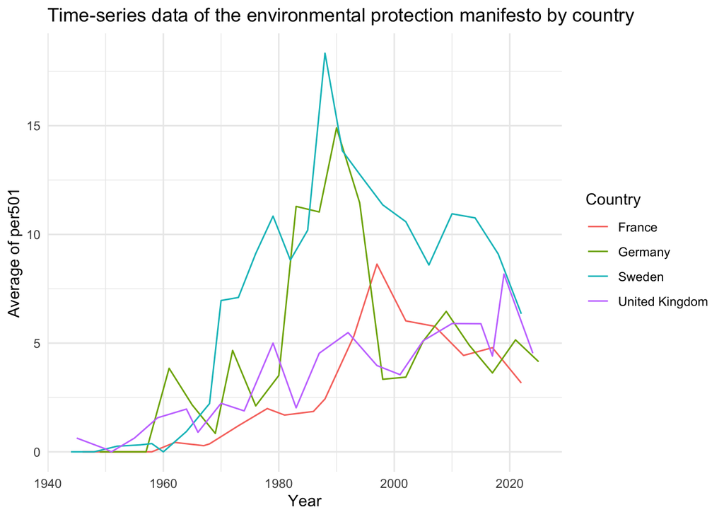

```r
# time-series data by country

country_mean <- country %>%
 group_by(countryname, year) %>%
 summarise(mean_per501 = mean(per501)) %>%
 ungroup()


 ggplot(country_mean, aes(x = year, y = mean_per501, colour = countryname)) +
 geom_line() +
  labs(title = "Time-series data of the environmental protection manifesto by country",
       x = "Year",
       y = "Average of per501",
       color = "Country") +
  theme_minimal()
```

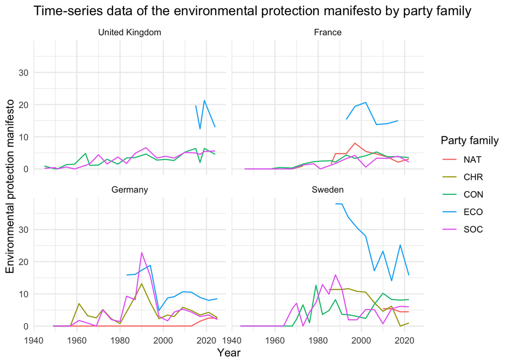

```r
# time-series data by party family

party_family <- country %>%
 mutate(parfam_label = case_when(
  parfam == 10 ~ "ECO",
  parfam == 30 ~ "SOC",
  parfam == 50 ~ "CHR",
  parfam == 60 ~ "CON",
  parfam == 70 ~ "NAT",
  TRUE ~ "Other"
 )) %>%
 filter(parfam_label != "Other")

## change of reference variables

party_family <- party_family %>%
 mutate(parfam_label = relevel(factor(parfam_label), ref = "NAT"),
        countryname = relevel(factor(countryname), ref = "United Kingdom"))

##
parfam_mean <- party_family %>%
 group_by(parfam_label, countryname, year) %>%
 summarise(mean_per501 = mean(per501)) %>%
 ungroup()


ggplot(parfam_mean,
       aes(x = year, y = mean_per501, colour = parfam_label)) +
 geom_line() +
 facet_wrap(~ countryname) +
 labs(
  title = "Time-series data of the environmental protection manifesto by party family",
  x = "Year",
  y = "Environmental protection manifesto",
  color = "Party family"
 ) +
 theme_minimal()
```